# individual-assignment-1

### Individual Assigment 1

#### Kevin Y. Li

This Kaggle dataset contains information on restaurants available through DoorDash in Canada. It includes 3,920 observations (restaurants) and 10 variables that help identify and assess whether to order from each restaurant. The variables in the dataset are:

- **Restaurant name** (categorical) The name of the restaurant.
- **DoorDash URL** (categorical) A unique link to the restaurant’s DoorDash page.
- **Distance to order** (numerical) Distance from specified point in the city to make an order (mile)
- **Star rating** (ordinal) Customer star rating out of 5 stars.
- **Number of reviews** (numerical) Number of reviews.
- **City** (categorical) The city where an order placed.
- **Price range** (categorical) Price range.
- **Cuisine/category 1** (categorical) Cuisine served at the restraunt.
- **Food specialization/category 2** (categorical) Food category/type served at the restraunt.

**Question: What factors contribute to a higher overall rating for a restraunt on Door Dash?**

This is an inference type question, with the main goal of identifying what aspects of a restraunt are associated with a higher Door Dash rating. In this context, a multiple linear regression could be the main model of interest for answering this quesiton.

```r
library(tidyverse)
library(haven)
library(ggplot2)
data_1 <- read.csv("data/cleaned_full_data.csv")
head(data_1)
```

A data.frame: 6 × 10

|  | X <int> | restaurant <chr> | url <chr> | distance <dbl> | star <dbl> | num_reviews <dbl> | city <chr> | price_range <chr> | category_1 <chr> | category_2 <chr> |
| --- | --- | --- | --- | --- | --- | --- | --- | --- | --- | --- |
| 1 | 0 | Sector 17 | https://www.doordash.com/store/884779/?pickup=false | 0.90 | 4.0 | 640 | Branpton | $$ | Indian | Wraps |
| 2 | 1 | Golden Palace Restaurant | https://www.doordash.com/store/332454/?pickup=false | 2.00 | 4.0 | 301 | Branpton | $$ | Chinese | Chicken |
| 3 | 2 | McDonald's | https://www.doordash.com/store/1140537/?pickup=false | 1.00 | 4.2 | 890 | Branpton | $$ | Bakery | Chicken |
| 4 | 3 | San Francisco Place | https://www.doordash.com/store/205349/?pickup=false | 0.40 | 4.4 | 109 | Branpton | $ | Italian | Sandwiches |
| 5 | 4 | THE BURGER BROS | https://www.doordash.com/store/940617/?pickup=false | 0.09 | 4.5 | 481 | Branpton | $$ | Fast Food | Sandwiches |
| 6 | 5 | Lazeez Shawarma | https://www.doordash.com/store/567102/?pickup=false | 0.90 | 3.7 | 730 | Branpton | $$ | Shawarma | Vegetarian |

```r
sum(is.na(data_1))
```

950

```r
tidy_data <- data_1 %>%
    rename(restaurant_name = restaurant, cuisine = category_1, food_specalization = category_2, distance_to_order = distance) %>%
    na.omit()
```

I believe a faceted scatter plot would be the most effective visualization for exploratory data analysis. It allows for the comparison of both categorical variables, such as the city location and price range of a restaurant, as well as numerical variables like the number of reviews, in relation to the target variable, overall restaurant rating. This type of visualization helps us understand how different types of variables influence the overall rating of a restaurant.

```r
variable_relationship_graph <- ggplot(tidy_data, aes(x=num_reviews, y=star, color = price_range)) +
    geom_point() +
    facet_wrap(~ city) +
    theme_minimal() +
    labs(title = "Star Rating VS. Number of Reviews, Price Range, and City",
        x = "Number of Reviews",
        y = "Star Rating",
        color = "Price Range") +
    theme(axis.text.x = element_text(angle = 45, hjust = 1, size = 16),
        axis.text.y = element_text(size = 16),
        axis.title.x = element_text(size = 16),
        axis.title.y = element_text(size = 16),
        strip.text = element_text(size = 16),
        plot.title = element_text(size = 26))
```

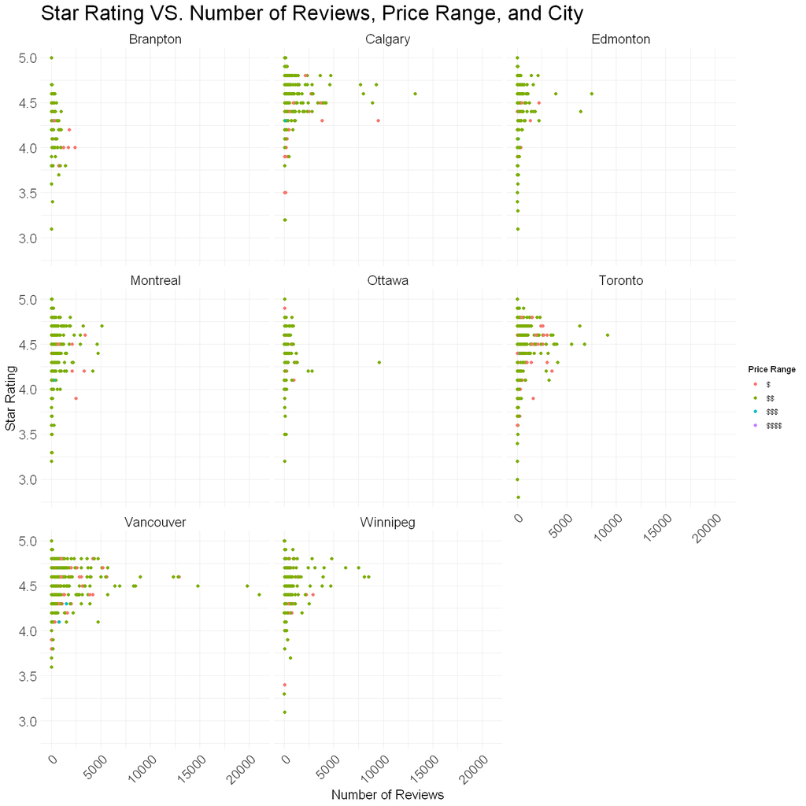

```r
options(repr.plot.width = 14, repr.plot.height = 14)

variable_relationship_graph
```

### Assignment 2

#### 1.

A multiple linear regression (MLR) model is an optimal method for analyzing the factors that contribute most to a higher overall star rating. Given that the target variable (star rating) is ordinal, ranging between 0.0 and 5.0, MLR is a suitable choice due to its ease of interpretation and ability to incorporate both numerical and categorical variables as predictors. Additionally, the model’s coefficients allow us to determine how each variable impacts a restaurant’s rating.

Assumptions of Multiple Linear Regression:

- There should be an approximately linear relationship between the predictors and the star rating.
- Observations should be independent of one another.
- The variance of errors should remain constant across all levels of each predictor (homoscedasticity).
- Predictors should not be highly correlated with one another (to avoid multicollinearity).
- The residuals (errors) should be approximately normally distributed.

Possible limitations of MLR:

- Star ratings can sometimes be interpreted as ordinal, which could violate linearity.
- Omitted variables Bias due to the limited nature of the dataset.
- Certain categorical features may be highly correlated, such as the price of a restraunt and the distance it is from the "city center".

```r
head(tidy_data)
```

A data.frame: 6 × 10

|  | X <int> | restaurant_name <chr> | url <chr> | distance_to_order <dbl> | star <dbl> | num_reviews <dbl> | city <chr> | price_range <chr> | cuisine <chr> | food_specalization <chr> |
| --- | --- | --- | --- | --- | --- | --- | --- | --- | --- | --- |
| 1 | 0 | Sector 17 | https://www.doordash.com/store/884779/?pickup=false | 0.90 | 4.0 | 640 | Branpton | $$ | Indian | Wraps |
| 2 | 1 | Golden Palace Restaurant | https://www.doordash.com/store/332454/?pickup=false | 2.00 | 4.0 | 301 | Branpton | $$ | Chinese | Chicken |
| 3 | 2 | McDonald's | https://www.doordash.com/store/1140537/?pickup=false | 1.00 | 4.2 | 890 | Branpton | $$ | Bakery | Chicken |
| 4 | 3 | San Francisco Place | https://www.doordash.com/store/205349/?pickup=false | 0.40 | 4.4 | 109 | Branpton | $ | Italian | Sandwiches |
| 5 | 4 | THE BURGER BROS | https://www.doordash.com/store/940617/?pickup=false | 0.09 | 4.5 | 481 | Branpton | $$ | Fast Food | Sandwiches |
| 6 | 5 | Lazeez Shawarma | https://www.doordash.com/store/567102/?pickup=false | 0.90 | 3.7 | 730 | Branpton | $$ | Shawarma | Vegetarian |

#### 2.

```r
tidy_data$city <- as.factor(tidy_data$city)
tidy_data$price_range <- as.factor(tidy_data$price_range)
tidy_data$cuisine <- as.factor(tidy_data$cuisine)
tidy_data$food_specalization <- as.factor(tidy_data$food_specalization)
tidy_data <- tidy_data %>% select(-restaurant_name, -url)
```

```r
model <- lm(star ~ ., data = tidy_data)
summary(model)
```

```
Call:
lm(formula = star ~ ., data = tidy_data)

Residuals:
     Min       1Q   Median       3Q      Max
-1.24335 -0.10031  0.00988  0.13565  0.74013

Coefficients: (12 not defined because of singularities)
                                              Estimate Std. Error t value
(Intercept)                                  4.005e+00  2.424e-01  16.526
X                                           -2.734e-04  3.773e-05  -7.247
distance_to_order                            8.308e-05  9.152e-04   0.091
num_reviews                                 -2.001e-07  4.463e-06  -0.045
cityCalgary                                  2.599e-01  3.203e-02   8.112
cityEdmonton                                 2.956e-01  3.848e-02   7.681
cityMontreal                                 4.017e-01  5.080e-02   7.906
cityOttawa                                   4.948e-01  6.636e-02   7.457
cityToronto                                  6.964e-01  7.563e-02   9.209
cityVancouver                                9.635e-01  1.053e-01   9.146
cityWinnipeg                                 1.057e+00  1.279e-01   8.261
price_range$$                                9.977e-02  1.808e-02   5.518
price_range$$$                              -9.142e-03  7.332e-02  -0.125
price_range$$$$                             -1.160e-01  2.007e-01  -0.578
cuisineAfghan                                3.118e-01  2.730e-01   1.142
cuisineAfrican                              -1.338e-01  2.658e-01  -0.503
cuisineAlcohol                               3.781e-01  2.499e-01   1.513
cuisineAmerican                              2.305e-01  2.486e-01   0.927
cuisineAmerican (Traditional)                1.856e-01  2.974e-01   0.624
cuisineAppetizers                            1.652e-01  2.668e-01   0.619
cuisineArgentine                             5.542e-01  3.616e-01   1.533
cuisineAsian                                 3.003e-01  2.658e-01   1.130
cuisineAsian Food                            5.710e-01  3.070e-01   1.860
cuisineAsian Fusion                          3.673e-01  2.525e-01   1.455
cuisineBagels                                2.438e-01  3.021e-01   0.807
cuisineBakeries                              3.406e-02  3.430e-01   0.099
cuisineBakery                                3.772e-01  2.491e-01   1.514
cuisineBaklava                               5.746e-01  3.541e-01   1.623
cuisineBanh Mi                               5.339e-01  3.580e-01   1.492
cuisineBar and Grill                         3.370e-01  2.601e-01   1.296
cuisineBarbecue                              3.653e-01  2.677e-01   1.365
```

[output cut: 903 more lines]

```
food_specalizationVermicelli                0.439583
food_specalizationVietnamese                0.180652
food_specalizationWaffles                   0.161938
food_specalizationWagyu                     0.064332 .
food_specalizationWine                      0.056166 .
food_specalizationWine & Spirits            0.174199
food_specalizationWings                     0.117960
food_specalizationWood Fire Pizza           0.591246
food_specalizationWraps                     0.000570 ***
---
Signif. codes:  0 '***' 0.001 '**' 0.01 '*' 0.05 '.' 0.1 ' ' 1

Residual standard error: 0.2417 on 2161 degrees of freedom
Multiple R-squared:  0.3781,	Adjusted R-squared:  0.2463
F-statistic: 2.869 on 458 and 2161 DF,  p-value: < 2.2e-16
```

```r
coef_df <- as.data.frame(coef(summary(model)))
coef_df <- coef_df[-1, ]
coef_df$Variable <- rownames(coef_df)
```

```r
coef_df <- as.data.frame(summary(model)$coefficients)
coef_df$Variable <- rownames(coef_df)

significant_coef <- coef_df %>% filter(`Pr(>|t|)` < 0.05)
significant_coef$Abs_Estimate <- abs(significant_coef$Estimate)

significant_coef <- significant_coef %>%
  arrange(desc(Abs_Estimate)) %>%
  head(10)
# significant_coef
# commented out the table because can use "only one table or visualization"
```

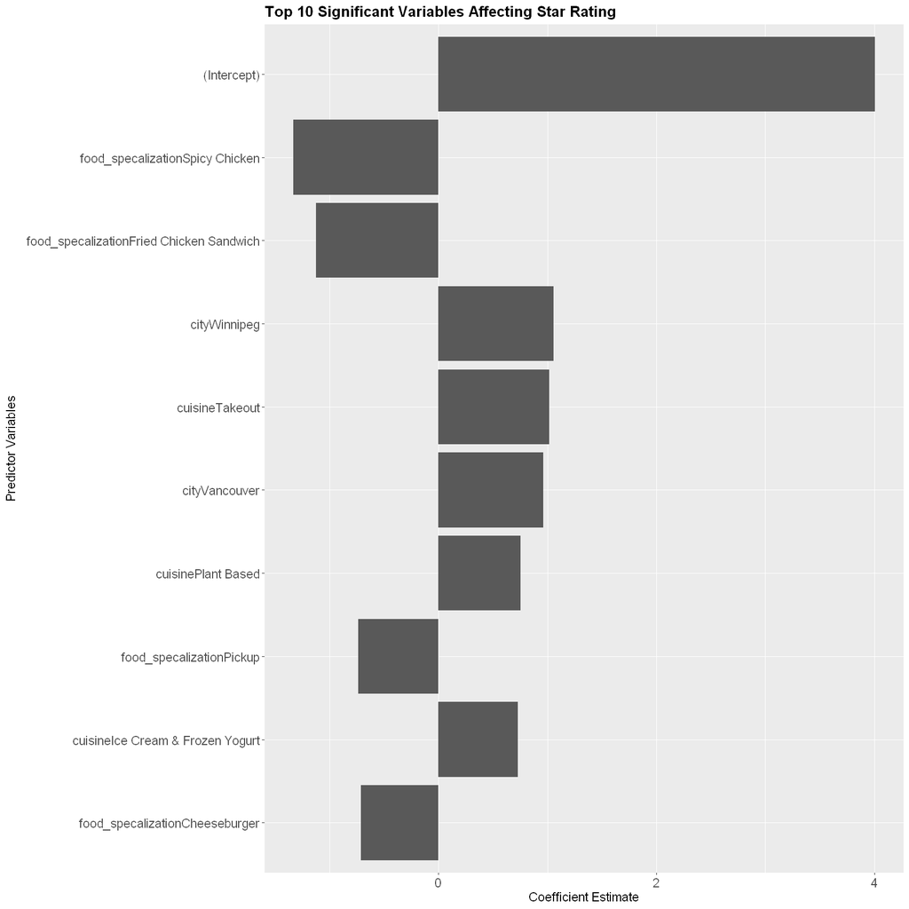

```r
ggplot(significant_coef, aes(x = reorder(Variable, Abs_Estimate), y = Estimate)) +
  geom_bar(stat = "identity") +
  coord_flip() +
  labs(title = "Top 10 Significant Variables Affecting Star Rating", x = "Predictor Variables", y = "Coefficient Estimate") +
  theme(
    plot.title = element_text(size = 16, face = "bold"),
    axis.title.x = element_text(size = 14),
    axis.title.y = element_text(size = 14),
    axis.text.x = element_text(size = 14),
    axis.text.y = element_text(size = 14))
```

Based on the visualization, the important factors that seem to affect a restraunt's star rating is not the number of reviews or the distance, but the city the restraunt is in and the cusine or food_specialization it has; however, the magnitude and direction of these effects vary significantly and are not entirely consistent. One potential issue that might be causing this is the high correlation between categorical variables, which might lead to multicollinearity impacting the model's accuracy.Furthermore, if we were to assume that star ratings are ordinal, using MLR might not be the best model to fit the data.

### Citations

Food Delivery across Canada (Door Dash). (n.d.). Www.kaggle.com. https://www.kaggle.com/datasets/satoshiss/food-delivery-in-canada-door-dash

‌